# Изучение закономерностей, определяющих успешность игр

# Table of Contents

## Описание проекта

Из открытых источников доступны исторические данные о продажах игр, оценки пользователей и экспертов, жанры и игровые платформы. Нужно выявить определяющие успешность игры закономерности. Это позволит сделать ставку на потенциально популярный продукт и спланировать рекламные кампании для интернет-магазина компьютерных игр, который продает игры по всему миру.

Данные до 2016 года. дата исследования - декабрь 2016 года, нуджно дать рекомендации для рекламной кампании на 2017 год.

## Описание данных

**Name** — название игры  
**Platform** — платформа  
**Year_of_Release** — год выпуска  
**Genre** — жанр игры  
**NA_sales** — продажи в Северной Америке (миллионы проданных копий)  
**EU_sales** — продажи в Европе (миллионы проданных копий)  
**JP_sales** — продажи в Японии (миллионы проданных копий)  
**Other_sales** — продажи в других странах (миллионы проданных копий)  
**Critic_Score** — оценка критиков (максимум 100)  
**User_Score** — оценка пользователей (максимум 10)  
**Rating** — рейтинг от организации ESRB (англ. Entertainment Software Rating Board). Эта ассоциация определяет рейтинг компьютерных игр и присваивает им подходящую возрастную категорию.

Данные за 2016 год могут быть неполными.

## Файл с данными

### Библиотеки

```python
import pandas as pd
import numpy as np
from scipy import stats as st
import matplotlib.pyplot as plt
```

Подгружаю файл с данными.

```python
df = pd.read_csv('games.csv')
df.info()
```

```
<class 'pandas.core.frame.DataFrame'>
RangeIndex: 16715 entries, 0 to 16714
Data columns (total 11 columns):
 #   Column           Non-Null Count  Dtype
---  ------           --------------  -----
 0   Name             16713 non-null  object
 1   Platform         16715 non-null  object
 2   Year_of_Release  16446 non-null  float64
 3   Genre            16713 non-null  object
 4   NA_sales         16715 non-null  float64
 5   EU_sales         16715 non-null  float64
 6   JP_sales         16715 non-null  float64
 7   Other_sales      16715 non-null  float64
 8   Critic_Score     8137 non-null   float64
 9   User_Score       10014 non-null  object
 10  Rating           9949 non-null   object
dtypes: float64(6), object(5)
memory usage: 1.4+ MB
```

```python
df.head()
```

|  | Name | Platform | Year_of_Release | Genre | NA_sales | EU_sales | JP_sales | Other_sales | Critic_Score | User_Score | Rating |
| --- | --- | --- | --- | --- | --- | --- | --- | --- | --- | --- | --- |
| 0 | Wii Sports | Wii | 2006.0 | Sports | 41.36 | 28.96 | 3.77 | 8.45 | 76.0 | 8 | E |
| 1 | Super Mario Bros. | NES | 1985.0 | Platform | 29.08 | 3.58 | 6.81 | 0.77 | NaN | NaN | NaN |
| 2 | Mario Kart Wii | Wii | 2008.0 | Racing | 15.68 | 12.76 | 3.79 | 3.29 | 82.0 | 8.3 | E |
| 3 | Wii Sports Resort | Wii | 2009.0 | Sports | 15.61 | 10.93 | 3.28 | 2.95 | 80.0 | 8 | E |
| 4 | Pokemon Red/Pokemon Blue | GB | 1996.0 | Role-Playing | 11.27 | 8.89 | 10.22 | 1.00 | NaN | NaN | NaN |

### Вывод

В таблице 16715 строк. Названия столбцов указаны с прописных букв, нужно будет испрвавить.  
В полях Name, Year_of_Release, Genre, Critic_Score, User_Score, Rating есть пропущенные значения.  
В поле Year_of_Release значение с типом float, так как это год выпуска игры, его можно перевести в тип integer.

## Подготовка данных

Привожу названия столбцов к нижнему регистру.

```python
df.columns = df.columns.str.lower()
df.info()
```

```
<class 'pandas.core.frame.DataFrame'>
RangeIndex: 16715 entries, 0 to 16714
Data columns (total 11 columns):
 #   Column           Non-Null Count  Dtype
---  ------           --------------  -----
 0   name             16713 non-null  object
 1   platform         16715 non-null  object
 2   year_of_release  16446 non-null  float64
 3   genre            16713 non-null  object
 4   na_sales         16715 non-null  float64
 5   eu_sales         16715 non-null  float64
 6   jp_sales         16715 non-null  float64
 7   other_sales      16715 non-null  float64
 8   critic_score     8137 non-null   float64
 9   user_score       10014 non-null  object
 10  rating           9949 non-null   object
dtypes: float64(6), object(5)
memory usage: 1.4+ MB
```

Проверяю датасет на наличие дубликатов.

```python
df.duplicated().sum()
```

```
0
```

Ищу дубликаты по паре имя-консоль

```python
df[['name','platform']].duplicated().sum()
```

```
5
```

Нашлись 5 дубликатов, удаляю их.

```python
df = df.drop_duplicates(subset = ['name','platform']).reset_index(drop=True)
```

### Обработка пропусков и замена типов данных (при необходимости)

### Столбец name

```python
df[df['name'].isna()]
```

|  | name | platform | year_of_release | genre | na_sales | eu_sales | jp_sales | other_sales | critic_score | user_score | rating |
| --- | --- | --- | --- | --- | --- | --- | --- | --- | --- | --- | --- |
| 659 | NaN | GEN | 1993.0 | NaN | 1.78 | 0.53 | 0.0 | 0.08 | NaN | NaN | NaN |

```python
df = df.dropna(subset=['name'])
df.info()
```

```
<class 'pandas.core.frame.DataFrame'>
Int64Index: 16709 entries, 0 to 16709
Data columns (total 11 columns):
 #   Column           Non-Null Count  Dtype
---  ------           --------------  -----
 0   name             16709 non-null  object
 1   platform         16709 non-null  object
 2   year_of_release  16441 non-null  float64
 3   genre            16709 non-null  object
 4   na_sales         16709 non-null  float64
 5   eu_sales         16709 non-null  float64
 6   jp_sales         16709 non-null  float64
 7   other_sales      16709 non-null  float64
 8   critic_score     8133 non-null   float64
 9   user_score       10010 non-null  object
 10  rating           9945 non-null   object
dtypes: float64(6), object(5)
memory usage: 1.5+ MB
```

### Столбец platform

```python
df.groupby('platform')['platform'].count()
```

```
platform
2600     133
3DO        3
3DS      520
DC        52
DS      2151
GB        98
GBA      822
GC       556
GEN       27
GG         1
N64      319
NES       98
NG        12
PC       973
PCFX       1
PS      1197
PS2     2161
PS3     1329
PS4      392
PSP     1209
PSV      430
SAT      173
SCD        6
SNES     239
TG16       2
WS         6
Wii     1320
WiiU     147
X360    1261
XB       824
XOne     247
Name: platform, dtype: int64
```

Пропущеных значений нет, аномалий нет, столбец можно оставить без изменений.  
Перехожу к следующему столбцу, в нем есть пропущенные значения.

```python
df.isna().sum()
```

```
name                  0
platform              0
year_of_release     268
genre                 0
na_sales              0
eu_sales              0
jp_sales              0
other_sales           0
critic_score       8576
user_score         6699
rating             6764
dtype: int64
```

### Столбец years_of_release

```python
df['year_of_release'] = df['year_of_release'].fillna(215200).astype('int')
```

```python
df.info()
```

```
<class 'pandas.core.frame.DataFrame'>
Int64Index: 16709 entries, 0 to 16709
Data columns (total 11 columns):
 #   Column           Non-Null Count  Dtype
---  ------           --------------  -----
 0   name             16709 non-null  object
 1   platform         16709 non-null  object
 2   year_of_release  16709 non-null  int32
 3   genre            16709 non-null  object
 4   na_sales         16709 non-null  float64
 5   eu_sales         16709 non-null  float64
 6   jp_sales         16709 non-null  float64
 7   other_sales      16709 non-null  float64
 8   critic_score     8133 non-null   float64
 9   user_score       10010 non-null  object
 10  rating           9945 non-null   object
dtypes: float64(5), int32(1), object(5)
memory usage: 1.5+ MB
```

### Столбец genre

```python
df.groupby('genre')['genre'].count()
```

```
genre
Action          3369
Adventure       1303
Fighting         849
Misc            1750
Platform         887
Puzzle           580
Racing          1247
Role-Playing    1498
Shooter         1323
Simulation       873
Sports          2347
Strategy         683
Name: genre, dtype: int64
```

Пропущенных значений нет, аномалий нет.

### Столбцы na_sales, eu_sales, jp_sales и other_sales

В столбцах na_sales, eu_sales, jp_sales и other_sales оставляю все без изменений, так как пропущенных значений нет.

### Столбец critic_score

```python
df['critic_score'].value_counts()
```

```
70.0    256
71.0    254
75.0    245
78.0    240
73.0    238
       ...
20.0      3
21.0      1
17.0      1
22.0      1
13.0      1
Name: critic_score, Length: 82, dtype: int64
```

```python
df[df['critic_score'].isna()]['name'].count()
```

```
8576
```

Оставляю пропущенные значения без изменения, так как это показатель того, что критикам эта игра не попадалась на оценку.

### Столбец user_score

```python
df['user_score'].value_counts()
```

```
tbd    2424
7.8     324
8       290
8.2     282
8.3     254
       ...
1.1       2
1.9       2
9.6       2
0         1
9.7       1
Name: user_score, Length: 96, dtype: int64
```

В строках появилось неопознанное значение tbd. Можно предположить, что это аббревиатура to be discussed или to be defined, что на момент выгрузки то же самое, что отсутствие оценки. Можно заменить tbd на NaN.  
Можно предположить, что остальные NaN появились потому что пользовательский рейтинг по данным играм не оценивался в тех источниках, из которых были получены данные.

```python
df['user_score'] = df['user_score'].replace('tbd', np.NaN).astype('float')
df['user_score'].value_counts()
```

```
7.8    324
8.0    290
8.2    282
8.3    254
8.5    251
      ...
1.5      2
0.3      2
1.1      2
0.0      1
9.7      1
Name: user_score, Length: 95, dtype: int64
```

```python
df.query('user_score==0') # или все очень плохо или это тоже NaN, так как такая игра только одна, оставляю ее как есть.
```

|  | name | platform | year_of_release | genre | na_sales | eu_sales | jp_sales | other_sales | critic_score | user_score | rating |
| --- | --- | --- | --- | --- | --- | --- | --- | --- | --- | --- | --- |
| 2834 | My Little Pony: Pinkie Pie's Party | DS | 2008 | Adventure | 0.66 | 0.0 | 0.0 | 0.06 | NaN | 0.0 | E |

```python
df.info()
```

```
<class 'pandas.core.frame.DataFrame'>
Int64Index: 16709 entries, 0 to 16709
Data columns (total 11 columns):
 #   Column           Non-Null Count  Dtype
---  ------           --------------  -----
 0   name             16709 non-null  object
 1   platform         16709 non-null  object
 2   year_of_release  16709 non-null  int32
 3   genre            16709 non-null  object
 4   na_sales         16709 non-null  float64
 5   eu_sales         16709 non-null  float64
 6   jp_sales         16709 non-null  float64
 7   other_sales      16709 non-null  float64
 8   critic_score     8133 non-null   float64
 9   user_score       7586 non-null   float64
 10  rating           9945 non-null   object
dtypes: float64(6), int32(1), object(4)
memory usage: 1.5+ MB
```

### Столбец rating

```python
df['rating'].value_counts()
```

```
E       3989
T       2959
M       1563
E10+    1419
EC         8
K-A        3
RP         3
AO         1
Name: rating, dtype: int64
```

По данным с [википедии](https://ru.wikipedia.org/wiki/Entertainment_Software_Rating_Board):

- RP - в данный момент игра находится на оценке в ESRB, это то же самое, что NAN
- K-A - то то же самое, что и Е.  
  Заменяю значения.

```python
df['rating'] = df['rating'].replace({'RP': np.NaN, 'K-A':'E'})
df['rating'].value_counts()
```

```
E       3992
T       2959
M       1563
E10+    1419
EC         8
AO         1
Name: rating, dtype: int64
```

## Расчет суммарных продаж во всех регионах

```python
df.head()
```

|  | name | platform | year_of_release | genre | na_sales | eu_sales | jp_sales | other_sales | critic_score | user_score | rating |
| --- | --- | --- | --- | --- | --- | --- | --- | --- | --- | --- | --- |
| 0 | Wii Sports | Wii | 2006 | Sports | 41.36 | 28.96 | 3.77 | 8.45 | 76.0 | 8.0 | E |
| 1 | Super Mario Bros. | NES | 1985 | Platform | 29.08 | 3.58 | 6.81 | 0.77 | NaN | NaN | NaN |
| 2 | Mario Kart Wii | Wii | 2008 | Racing | 15.68 | 12.76 | 3.79 | 3.29 | 82.0 | 8.3 | E |
| 3 | Wii Sports Resort | Wii | 2009 | Sports | 15.61 | 10.93 | 3.28 | 2.95 | 80.0 | 8.0 | E |
| 4 | Pokemon Red/Pokemon Blue | GB | 1996 | Role-Playing | 11.27 | 8.89 | 10.22 | 1.00 | NaN | NaN | NaN |

Добавляю столбец с суммарными продажами игр по всем регионам.

```python
df['all_sales'] = df['na_sales'] + df['eu_sales'] + df['jp_sales'] + df['other_sales']
df.head()
```

|  | name | platform | year_of_release | genre | na_sales | eu_sales | jp_sales | other_sales | critic_score | user_score | rating | all_sales |
| --- | --- | --- | --- | --- | --- | --- | --- | --- | --- | --- | --- | --- |
| 0 | Wii Sports | Wii | 2006 | Sports | 41.36 | 28.96 | 3.77 | 8.45 | 76.0 | 8.0 | E | 82.54 |
| 1 | Super Mario Bros. | NES | 1985 | Platform | 29.08 | 3.58 | 6.81 | 0.77 | NaN | NaN | NaN | 40.24 |
| 2 | Mario Kart Wii | Wii | 2008 | Racing | 15.68 | 12.76 | 3.79 | 3.29 | 82.0 | 8.3 | E | 35.52 |
| 3 | Wii Sports Resort | Wii | 2009 | Sports | 15.61 | 10.93 | 3.28 | 2.95 | 80.0 | 8.0 | E | 32.77 |
| 4 | Pokemon Red/Pokemon Blue | GB | 1996 | Role-Playing | 11.27 | 8.89 | 10.22 | 1.00 | NaN | NaN | NaN | 31.38 |

## Обновление индексов

```python
df = df.reset_index(drop=True)
```

## Исследовательский анализ данных

### Оценка количества игр, выпущенных в разные годы

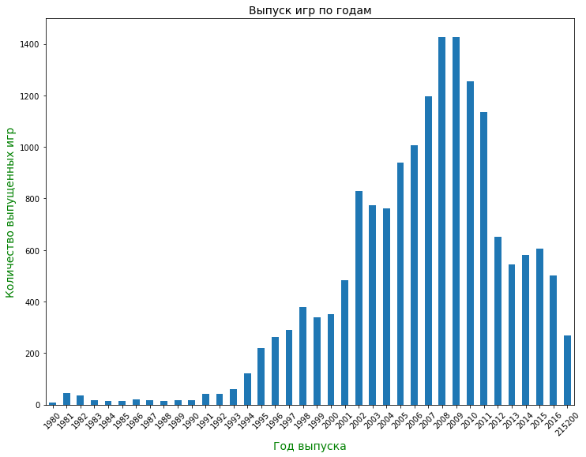

```python
df.groupby('year_of_release')['name'].count().plot(kind = 'bar', figsize = (12,9))
plt.title('Выпуск игр по годам', fontsize = 14)
plt.xlabel('Год выпуска', color = 'green', fontsize = 14)
plt.ylabel('Количество выпущенных игр', color = 'green', fontsize = 14)
plt.xticks(rotation = 45);
```

#### Вывод

Начиная с 1994 года начинается рост выпуска игр. Больше всего игр выпустили в 2008 и 2009 году.

Для планирования рекламного бюджета на 2017 год не стоит рассматривать игры, выпущенные раньше 2002 года. В 2002 году произошло резкое увеличение выпуска игр.  
Смотрю, сколько строк останется в выборке, если ее ограничить 2002 годом и убрать те игры, для которых год выпуска не был указан.

```python
df.query('2002 <=year_of_release<215200')['name'].count()
```

```
13635
```

```python
df_15_years = df.query('2002 <=year_of_release<215200')
```

### Оценка изменений продаж по платформам

Нахожу Топ-10 платформ с наибольшими продажами.

```python
top_10_platform = df_15_years.pivot_table(index = 'platform', values = 'all_sales', aggfunc = 'sum').sort_values(by='all_sales', ascending = False).head(10)
top_10_platform
```

| platform | all_sales |
| --- | --- |
| PS2 | 1027.96 |
| X360 | 959.99 |
| PS3 | 931.33 |
| Wii | 891.18 |
| DS | 802.76 |
| PS4 | 314.14 |
| PSP | 289.53 |
| 3DS | 257.81 |
| GBA | 251.28 |
| XB | 228.32 |

Строю график для наглядности.

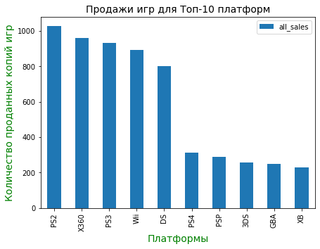

```python
top_10_platform.plot(kind = 'bar',figsize = (7,5))
plt.title('Продажи игр для Топ-10 платформ', fontsize = 14)
plt.xlabel('Платформы', color = 'green', fontsize = 14)
plt.ylabel('Количество проданных копий игр', color = 'green', fontsize = 14);
```

Оставляю в таблице за последние 15 лет только Топ-10 платформ.

```python
df_actual = (df_15_years.join(top_10_platform, on ='platform', how = 'right', lsuffix = '_region', rsuffix='_platform')
             .reset_index(drop=True))
df_actual.head()
```

|  | name | platform | year_of_release | genre | na_sales | eu_sales | jp_sales | other_sales | critic_score | user_score | rating | all_sales_region | all_sales_platform |
| --- | --- | --- | --- | --- | --- | --- | --- | --- | --- | --- | --- | --- | --- |
| 0 | Grand Theft Auto: San Andreas | PS2 | 2004 | Action | 9.43 | 0.40 | 0.41 | 10.57 | 95.0 | 9.0 | M | 20.81 | 1027.96 |
| 1 | Grand Theft Auto: Vice City | PS2 | 2002 | Action | 8.41 | 5.49 | 0.47 | 1.78 | 95.0 | 8.7 | M | 16.15 | 1027.96 |
| 2 | Gran Turismo 4 | PS2 | 2004 | Racing | 3.01 | 0.01 | 1.10 | 7.53 | 89.0 | 8.5 | E | 11.65 | 1027.96 |
| 3 | Need for Speed Underground | PS2 | 2003 | Racing | 3.27 | 2.83 | 0.08 | 1.02 | 85.0 | 8.6 | E | 7.20 | 1027.96 |
| 4 | Need for Speed Underground 2 | PS2 | 2004 | Racing | 2.71 | 3.02 | 0.08 | 1.09 | 82.0 | 8.6 | E | 6.90 | 1027.96 |

Строю сводную таблицу по платформам и годам.

```python
years_platforms = df_actual.pivot_table(index = ['platform','year_of_release'], values = 'name', aggfunc = 'count')
years_platforms.head(10)
```

| platform | year_of_release | name |
| --- | --- | --- |
| 3DS | 2011 | 116 |
|  | 2012 | 93 |
|  | 2013 | 91 |
|  | 2014 | 80 |
|  | 2015 | 86 |
|  | 2016 | 46 |
| DS | 2004 | 23 |
|  | 2005 | 118 |
|  | 2006 | 201 |
|  | 2007 | 376 |

Смотрю, сколько лет для платформы выпускаеются игры.

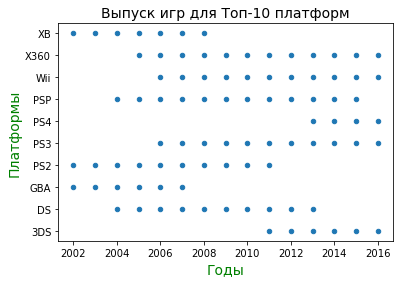

```python
years_platforms.reset_index().plot(x = 'year_of_release', y = 'platform', kind="scatter")
plt.title('Выпуск игр для Топ-10 платформ', fontsize = 14)
plt.xlabel('Годы', color = 'green', fontsize = 14)
plt.ylabel('Платформы', color = 'green', fontsize = 14);
```

Для многих приставок игры выпускаются более 10 лет.  
Выборку в 15 лет можно считать репрезентативной, но некотрые платформы прекратили свое существование и прогноз по продажам игр для них на 2017 год будет неактуальным. Таким образом, оставляю выборку по годам, начиная с 2006 года, но возвращаю все платформы.

```python
life_cycle = (df.query('year_of_release !=215200')
.pivot_table(index = ['platform'], values = 'year_of_release', aggfunc = ['min','max']))
life_cycle.columns = ['start_of_sales','end_of_sales']
life_cycle['life_cycle'] = life_cycle['end_of_sales'] - life_cycle['start_of_sales']
life_cycle
```

| platform | start_of_sales | end_of_sales | life_cycle |
| --- | --- | --- | --- |
| 2600 | 1980 | 1989 | 9 |
| 3DO | 1994 | 1995 | 1 |
| 3DS | 2011 | 2016 | 5 |
| DC | 1998 | 2008 | 10 |
| DS | 1985 | 2013 | 28 |
| GB | 1988 | 2001 | 13 |
| GBA | 2000 | 2007 | 7 |
| GC | 2001 | 2007 | 6 |
| GEN | 1990 | 1994 | 4 |
| GG | 1992 | 1992 | 0 |
| N64 | 1996 | 2002 | 6 |
| NES | 1983 | 1994 | 11 |
| NG | 1993 | 1996 | 3 |
| PC | 1985 | 2016 | 31 |
| PCFX | 1996 | 1996 | 0 |
| PS | 1994 | 2003 | 9 |
| PS2 | 2000 | 2011 | 11 |
| PS3 | 2006 | 2016 | 10 |
| PS4 | 2013 | 2016 | 3 |
| PSP | 2004 | 2015 | 11 |
| PSV | 2011 | 2016 | 5 |
| SAT | 1994 | 1999 | 5 |
| SCD | 1993 | 1994 | 1 |
| SNES | 1990 | 1999 | 9 |
| TG16 | 1995 | 1995 | 0 |
| WS | 1999 | 2001 | 2 |
| Wii | 2006 | 2016 | 10 |
| WiiU | 2012 | 2016 | 4 |
| X360 | 2005 | 2016 | 11 |
| XB | 2000 | 2008 | 8 |
| XOne | 2013 | 2016 | 3 |

```python
print('Средний срок жизни платформы:', life_cycle['life_cycle'].median()) #беру медиану, т.к. некоторые платформы очень живучие
```

```
Средний срок жизни платформы: 6.0
```

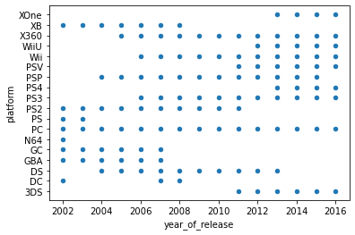

```python
platforms_15_year = df_15_years.pivot_table(index = ['platform','year_of_release'], values = 'name', aggfunc = 'count')
platforms_15_year.reset_index().plot(x = 'year_of_release', y = 'platform', kind="scatter")
```

Нахожу список живых платформ на 2016 год. Среди них нужно искать рост и падение продаж, так как платформы, которые уже не выпускаются, точно не должны иметь рост продаж в 2017 году.

```python
list_platform = df.query('year_of_release == 2016')['platform'].unique()
list_platform
```

```
array(['PS4', '3DS', 'XOne', 'WiiU', 'PS3', 'PC', 'X360', 'PSV', 'Wii'],
      dtype=object)
```

Обновляю выборку, по которой буду проводить исследование, ограничивая ее 2006 годом.

```python
(df.query('genre == "Strategy"') #обоснование к комментарию выше
 .pivot_table(index = 'platform', values = 'genre', aggfunc = 'count')
 .sort_values(by='genre', ascending=False).head())
```

| platform | genre |
| --- | --- |
| PC | 188 |
| DS | 79 |
| PS | 71 |
| PS2 | 71 |
| PSP | 60 |

```python
(df.query('genre == "Sports"') #обоснование к комментарию выше
 .pivot_table(index = 'platform', values = 'genre', aggfunc = 'count')
 .sort_values(by='genre', ascending=False).head())
```

| platform | genre |
| --- | --- |
| PS2 | 400 |
| Wii | 260 |
| PS | 222 |
| X360 | 217 |
| PS3 | 213 |

```python
(df.query('platform == "Wii"') #обоснование к комментарию выше
 .pivot_table(index = 'genre', values = 'platform', aggfunc = 'count')
 .sort_values(by='platform', ascending=False).head())
```

| genre | platform |
| --- | --- |
| Misc | 280 |
| Sports | 260 |
| Action | 237 |
| Racing | 93 |
| Simulation | 87 |

```python
df_actual = df.query('platform in @list_platform and year_of_release>=2006').reset_index(drop=True)
df_actual
```

|  | name | platform | year_of_release | genre | na_sales | eu_sales | jp_sales | other_sales | critic_score | user_score | rating | all_sales |
| --- | --- | --- | --- | --- | --- | --- | --- | --- | --- | --- | --- | --- |
| 0 | Wii Sports | Wii | 2006 | Sports | 41.36 | 28.96 | 3.77 | 8.45 | 76.0 | 8.0 | E | 82.54 |
| 1 | Mario Kart Wii | Wii | 2008 | Racing | 15.68 | 12.76 | 3.79 | 3.29 | 82.0 | 8.3 | E | 35.52 |
| 2 | Wii Sports Resort | Wii | 2009 | Sports | 15.61 | 10.93 | 3.28 | 2.95 | 80.0 | 8.0 | E | 32.77 |
| 3 | Wii Play | Wii | 2006 | Misc | 13.96 | 9.18 | 2.93 | 2.84 | 58.0 | 6.6 | E | 28.91 |
| 4 | New Super Mario Bros. Wii | Wii | 2009 | Platform | 14.44 | 6.94 | 4.70 | 2.24 | 87.0 | 8.4 | E | 28.32 |
| ... | ... | ... | ... | ... | ... | ... | ... | ... | ... | ... | ... | ... |
| 6416 | Aiyoku no Eustia | PSV | 2014 | Misc | 0.00 | 0.00 | 0.01 | 0.00 | NaN | NaN | NaN | 0.01 |
| 6417 | Samurai Warriors: Sanada Maru | PS3 | 2016 | Action | 0.00 | 0.00 | 0.01 | 0.00 | NaN | NaN | NaN | 0.01 |
| 6418 | LMA Manager 2007 | X360 | 2006 | Sports | 0.00 | 0.01 | 0.00 | 0.00 | NaN | NaN | NaN | 0.01 |
| 6419 | Haitaka no Psychedelica | PSV | 2016 | Adventure | 0.00 | 0.00 | 0.01 | 0.00 | NaN | NaN | NaN | 0.01 |
| 6420 | Winning Post 8 2016 | PSV | 2016 | Simulation | 0.00 | 0.00 | 0.01 | 0.00 | NaN | NaN | NaN | 0.01 |

6421 rows × 12 columns

### Альтернативная выборка за 5 лет 🎈🎈🎈

```python
df_alternative = df.query('platform in @list_platform and year_of_release>=2011').reset_index(drop=True) #альтернативная выборка
df_alternative # осталось в 2 раза меньше строк, далее буду помечать ее как АВ
```

|  | name | platform | year_of_release | genre | na_sales | eu_sales | jp_sales | other_sales | critic_score | user_score | rating | all_sales |
| --- | --- | --- | --- | --- | --- | --- | --- | --- | --- | --- | --- | --- |
| 0 | Grand Theft Auto V | PS3 | 2013 | Action | 7.02 | 9.09 | 0.98 | 3.96 | 97.0 | 8.2 | M | 21.05 |
| 1 | Grand Theft Auto V | X360 | 2013 | Action | 9.66 | 5.14 | 0.06 | 1.41 | 97.0 | 8.1 | M | 16.27 |
| 2 | Call of Duty: Modern Warfare 3 | X360 | 2011 | Shooter | 9.04 | 4.24 | 0.13 | 1.32 | 88.0 | 3.4 | M | 14.73 |
| 3 | Call of Duty: Black Ops 3 | PS4 | 2015 | Shooter | 6.03 | 5.86 | 0.36 | 2.38 | NaN | NaN | NaN | 14.63 |
| 4 | Pokemon X/Pokemon Y | 3DS | 2013 | Role-Playing | 5.28 | 4.19 | 4.35 | 0.78 | NaN | NaN | NaN | 14.60 |
| ... | ... | ... | ... | ... | ... | ... | ... | ... | ... | ... | ... | ... |
| 3626 | Strawberry Nauts | PSV | 2016 | Adventure | 0.00 | 0.00 | 0.01 | 0.00 | NaN | NaN | NaN | 0.01 |
| 3627 | Aiyoku no Eustia | PSV | 2014 | Misc | 0.00 | 0.00 | 0.01 | 0.00 | NaN | NaN | NaN | 0.01 |
| 3628 | Samurai Warriors: Sanada Maru | PS3 | 2016 | Action | 0.00 | 0.00 | 0.01 | 0.00 | NaN | NaN | NaN | 0.01 |
| 3629 | Haitaka no Psychedelica | PSV | 2016 | Adventure | 0.00 | 0.00 | 0.01 | 0.00 | NaN | NaN | NaN | 0.01 |
| 3630 | Winning Post 8 2016 | PSV | 2016 | Simulation | 0.00 | 0.00 | 0.01 | 0.00 | NaN | NaN | NaN | 0.01 |

3631 rows × 12 columns

### Определение роста и падения продаж

```python
(df_actual
 .pivot_table(index = 'platform', values = 'all_sales', aggfunc = 'sum')
 .sort_values(by='all_sales', ascending = False).head(10)) # нахожу топ-10 по продажам
```

| platform | all_sales |
| --- | --- |
| X360 | 963.17 |
| PS3 | 939.16 |
| Wii | 907.51 |
| PS4 | 314.14 |
| 3DS | 259.00 |
| PC | 167.10 |
| XOne | 159.32 |
| WiiU | 82.19 |
| PSV | 54.07 |

```python
(df_alternative
 .pivot_table(index = 'platform', values = 'all_sales', aggfunc = 'sum')
 .sort_values(by='all_sales', ascending = False).head(10)) # нахожу топ-10 по продажам
```

| platform | all_sales |
| --- | --- |
| PS3 | 453.39 |
| X360 | 390.56 |
| PS4 | 314.14 |
| 3DS | 259.00 |
| XOne | 159.32 |
| Wii | 111.35 |
| PC | 101.36 |
| WiiU | 82.19 |
| PSV | 54.07 |

#### X360 🎈

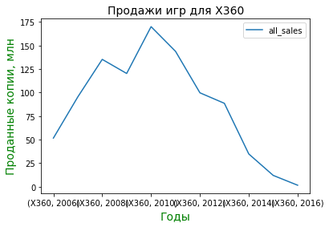

```python
(df_actual.query('platform == "X360" and year_of_release !=215200')
 .pivot_table(index = ['platform', 'year_of_release'], values= 'all_sales',aggfunc = 'sum' )
 .plot())
plt.title('Продажи игр для X360', fontsize = 14)
plt.xlabel('Годы', color = 'green', fontsize = 14)
plt.ylabel('Проданные копии, млн', color = 'green', fontsize = 14);
```

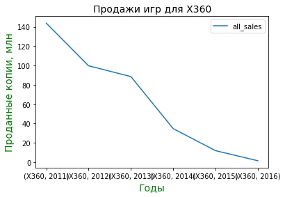

```python
(df_alternative.query('platform == "X360" and year_of_release !=215200')
 .pivot_table(index = ['platform', 'year_of_release'], values= 'all_sales',aggfunc = 'sum' )
 .plot())
plt.title('Продажи игр для X360', fontsize = 14)
plt.xlabel('Годы', color = 'green', fontsize = 14)
plt.ylabel('Проданные копии, млн', color = 'green', fontsize = 14);
```

##### Вывод АВ 🎈

На альтернативной выборке наблюдается плавное падение продаж для X360 от пика продаж в 2011 году.

#### PS3 🎈

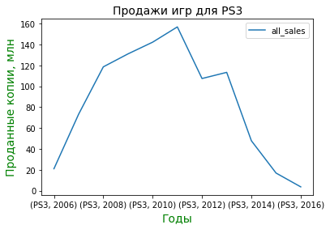

```python
(df_actual.query('platform == "PS3" and year_of_release !=215200')
 .pivot_table(index = ['platform', 'year_of_release'], values= 'all_sales',aggfunc = 'sum' )
 .plot())
plt.title('Продажи игр для PS3', fontsize = 14)
plt.xlabel('Годы', color = 'green', fontsize = 14)
plt.ylabel('Проданные копии, млн', color = 'green', fontsize = 14);
```

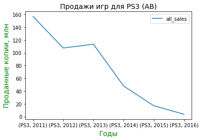

```python
(df_alternative.query('platform == "PS3" and year_of_release !=215200')
 .pivot_table(index = ['platform', 'year_of_release'], values= 'all_sales',aggfunc = 'sum' )
 .plot())
plt.title('Продажи игр для PS3 (АВ)', fontsize = 14)
plt.xlabel('Годы', color = 'green', fontsize = 14)
plt.ylabel('Проданные копии, млн', color = 'green', fontsize = 14);
```

#### Wii

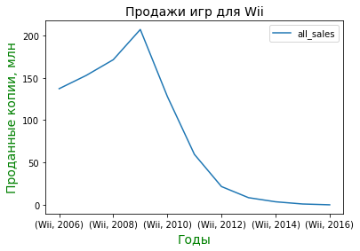

```python
(df_actual.query('platform == "Wii" and year_of_release !=215200')
 .pivot_table(index = ['platform', 'year_of_release'], values= 'all_sales',aggfunc = 'sum' )
 .plot())
plt.title('Продажи игр для Wii', fontsize = 14)
plt.xlabel('Годы', color = 'green', fontsize = 14)
plt.ylabel('Проданные копии, млн', color = 'green', fontsize = 14);
```

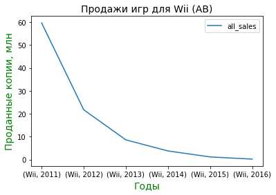

```python
(df_alternative.query('platform == "Wii" and year_of_release !=215200')
 .pivot_table(index = ['platform', 'year_of_release'], values= 'all_sales',aggfunc = 'sum' )
 .plot())
plt.title('Продажи игр для Wii (АВ)', fontsize = 14)
plt.xlabel('Годы', color = 'green', fontsize = 14)
plt.ylabel('Проданные копии, млн', color = 'green', fontsize = 14);
```

#### PS4 🎈

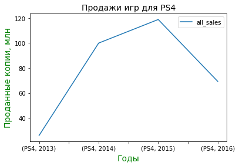

```python
(df_actual.query('platform == "PS4" and year_of_release !=215200')
 .pivot_table(index = ['platform', 'year_of_release'], values= 'all_sales',aggfunc = 'sum' )
 .plot())
plt.title('Продажи игр для PS4', fontsize = 14)
plt.xlabel('Годы', color = 'green', fontsize = 14)
plt.ylabel('Проданные копии, млн', color = 'green', fontsize = 14);
```

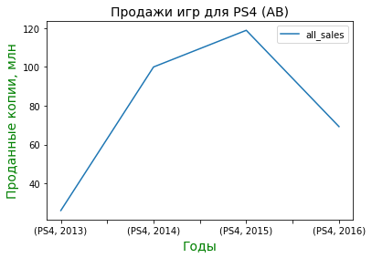

```python
(df_alternative.query('platform == "PS4" and year_of_release !=215200')
 .pivot_table(index = ['platform', 'year_of_release'], values= 'all_sales',aggfunc = 'sum' )
 .plot())
plt.title('Продажи игр для PS4 (АВ)', fontsize = 14)
plt.xlabel('Годы', color = 'green', fontsize = 14)
plt.ylabel('Проданные копии, млн', color = 'green', fontsize = 14);
```

##### Вывод 🎈

График без изменений.

#### 3DS 🎈

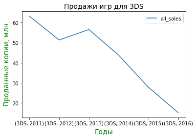

```python
(df_actual.query('platform == "3DS" and year_of_release !=215200')
 .pivot_table(index = ['platform', 'year_of_release'], values= 'all_sales',aggfunc = 'sum' )
 .plot())
plt.title('Продажи игр для 3DS', fontsize = 14)
plt.xlabel('Годы', color = 'green', fontsize = 14)
plt.ylabel('Проданные копии, млн', color = 'green', fontsize = 14);
```

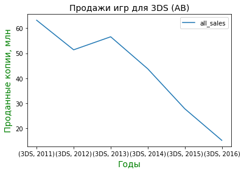

```python
(df_alternative.query('platform == "3DS" and year_of_release !=215200')
 .pivot_table(index = ['platform', 'year_of_release'], values= 'all_sales',aggfunc = 'sum' )
 .plot())
plt.title('Продажи игр для 3DS (АВ)', fontsize = 14)
plt.xlabel('Годы', color = 'green', fontsize = 14)
plt.ylabel('Проданные копии, млн', color = 'green', fontsize = 14);
```

##### Вывод 🎈

График без изменений.

#### XOne 🎈

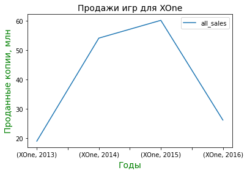

```python
(df_actual.query('platform == "XOne" and year_of_release !=215200')
 .pivot_table(index = ['platform', 'year_of_release'], values= 'all_sales',aggfunc = 'sum' )
 .plot())
plt.title('Продажи игр для XOne', fontsize = 14)
plt.xlabel('Годы', color = 'green', fontsize = 14)
plt.ylabel('Проданные копии, млн', color = 'green', fontsize = 14);
```

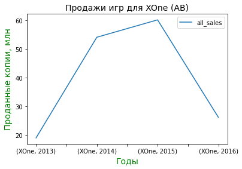

```python
(df_alternative.query('platform == "XOne" and year_of_release !=215200')
 .pivot_table(index = ['platform', 'year_of_release'], values= 'all_sales',aggfunc = 'sum' )
 .plot())
plt.title('Продажи игр для XOne (АВ)', fontsize = 14)
plt.xlabel('Годы', color = 'green', fontsize = 14)
plt.ylabel('Проданные копии, млн', color = 'green', fontsize = 14);
```

##### Вывод 🎈

График без изменений.

#### WiiU 🎈

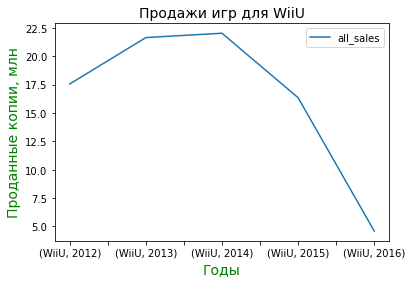

```python
(df_actual.query('platform == "WiiU" and year_of_release !=215200')
 .pivot_table(index = ['platform', 'year_of_release'], values= 'all_sales',aggfunc = 'sum' )
 .plot())
plt.title('Продажи игр для WiiU', fontsize = 14)
plt.xlabel('Годы', color = 'green', fontsize = 14)
plt.ylabel('Проданные копии, млн', color = 'green', fontsize = 14);
```

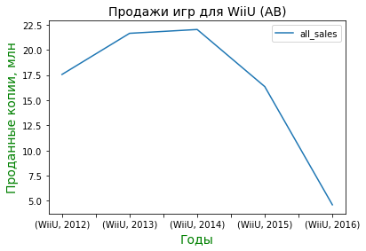

```python
(df_alternative.query('platform == "WiiU" and year_of_release !=215200')
 .pivot_table(index = ['platform', 'year_of_release'], values= 'all_sales',aggfunc = 'sum' )
 .plot())
plt.title('Продажи игр для WiiU (АВ)', fontsize = 14)
plt.xlabel('Годы', color = 'green', fontsize = 14)
plt.ylabel('Проданные копии, млн', color = 'green', fontsize = 14);
```

##### Вывод 🎈

График без изменений.

#### PC 🎈

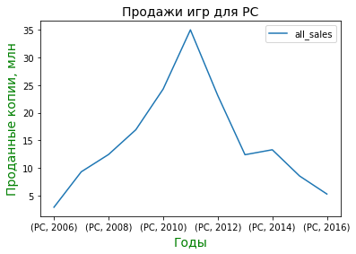

```python
(df_actual.query('platform == "PC" and year_of_release !=215200')
 .pivot_table(index = ['platform', 'year_of_release'], values= 'all_sales',aggfunc = 'sum' )
 .plot())
plt.title('Продажи игр для PC', fontsize = 14)
plt.xlabel('Годы', color = 'green', fontsize = 14)
plt.ylabel('Проданные копии, млн', color = 'green', fontsize = 14);
```

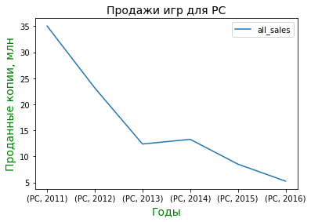

```python
(df_alternative.query('platform == "PC" and year_of_release !=215200')
 .pivot_table(index = ['platform', 'year_of_release'], values= 'all_sales',aggfunc = 'sum' )
 .plot())
plt.title('Продажи игр для PC', fontsize = 14)
plt.xlabel('Годы', color = 'green', fontsize = 14)
plt.ylabel('Проданные копии, млн', color = 'green', fontsize = 14);
```

##### Вывод АВ 🎈

На альтернативной выборке наблюдается плавное падение продаж для PC от пика продаж в 2011 году.

#### PSV🎈

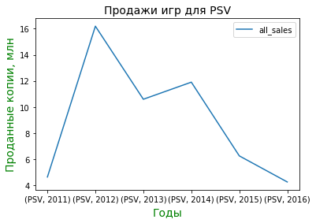

```python
(df_actual.query('platform == "PSV" and year_of_release !=215200')
 .pivot_table(index = ['platform', 'year_of_release'], values= 'all_sales',aggfunc = 'sum' )
 .plot())
plt.title('Продажи игр для PSV', fontsize = 14)
plt.xlabel('Годы', color = 'green', fontsize = 14)
plt.ylabel('Проданные копии, млн', color = 'green', fontsize = 14);
```

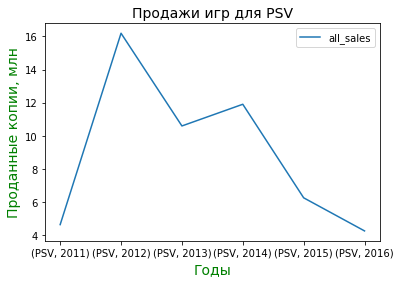

```python
(df_alternative.query('platform == "PSV" and year_of_release !=215200')
 .pivot_table(index = ['platform', 'year_of_release'], values= 'all_sales',aggfunc = 'sum' )
 .plot())
plt.title('Продажи игр для PSV', fontsize = 14)
plt.xlabel('Годы', color = 'green', fontsize = 14)
plt.ylabel('Проданные копии, млн', color = 'green', fontsize = 14);
```

##### Вывод АВ 🎈

График остался практически без изменений, общая тенденция после 2011 года сохраняется.

### Вывод

**Рост продаж** наблюдается у PS4 и XOne  
**Падение продаж** у 3DS, WiiU, PS3, X360, PSV, Wii

🎈 В целом вывод не поменялся

```python
# КОД РЕВЬЮЕРА

df_actual.pivot_table(index='year_of_release', columns='platform', values='all_sales', aggfunc='sum').loc[[2015, 2016]]
```

| platform year_of_release | 3DS | PC | PS3 | PS4 | PSV | Wii | WiiU | X360 | XOne |
| --- | --- | --- | --- | --- | --- | --- | --- | --- | --- |
| 2015 | 27.78 | 8.52 | 16.82 | 118.90 | 6.25 | 1.14 | 16.35 | 11.96 | 60.14 |
| 2016 | 15.14 | 5.25 | 3.60 | 69.25 | 4.25 | 0.18 | 4.60 | 1.52 | 26.15 |

### Опредение платформ, лидирующих по продажам

#### Платформы, для которых выпускались игры в 2016 году

```python
platforms_2016 = (df_actual.pivot_table(index = 'platform', values = 'all_sales', aggfunc = 'sum')
                  .sort_values(by = 'all_sales', ascending = False))
platforms_2016
```

| platform | all_sales |
| --- | --- |
| X360 | 963.17 |
| PS3 | 939.16 |
| Wii | 907.51 |
| PS4 | 314.14 |
| 3DS | 259.00 |
| PC | 167.10 |
| XOne | 159.32 |
| WiiU | 82.19 |
| PSV | 54.07 |

```python
platforms_2016_ab = (df_alternative.pivot_table(index = 'platform', values = 'all_sales', aggfunc = 'sum')
                     .sort_values(by = 'all_sales', ascending = False))
platforms_2016_ab
```

| platform | all_sales |
| --- | --- |
| PS3 | 453.39 |
| X360 | 390.56 |
| PS4 | 314.14 |
| 3DS | 259.00 |
| XOne | 159.32 |
| Wii | 111.35 |
| PC | 101.36 |
| WiiU | 82.19 |
| PSV | 54.07 |

#### Рейтинг продаж по всем платформам за все годы

```python
(df.pivot_table(index = 'platform', values = 'all_sales', aggfunc = 'sum')
.sort_values(by = 'all_sales', ascending = False).head(10))
```

| platform | all_sales |
| --- | --- |
| PS2 | 1255.77 |
| X360 | 970.17 |
| PS3 | 939.16 |
| Wii | 907.51 |
| DS | 806.12 |
| PS | 730.86 |
| GBA | 317.85 |
| PS4 | 314.14 |
| PSP | 294.05 |
| PC | 259.44 |

### Вывод

Из работающих на 2016 год платформ, наибольшие продажи у X360, PS3 и **Wii**.  
За весь период наблюдений самые большие продажи были у PS2, X360 и PS3.

Беру TOP-5 платформ, для которых провожу дальнейшее исследование.

🎈 Из работающих на 2016 год платформ, наибольшие продажи у X360, PS3 и **PS4**. Остальные наблюдения без изменений.

```python
top_5 = platforms_2016.head()
top_5
```

| platform | all_sales |
| --- | --- |
| X360 | 963.17 |
| PS3 | 939.16 |
| Wii | 907.51 |
| PS4 | 314.14 |
| 3DS | 259.00 |

```python
top_5_ab = platforms_2016_ab.head()
top_5_ab
```

| platform | all_sales |
| --- | --- |
| PS3 | 453.39 |
| X360 | 390.56 |
| PS4 | 314.14 |
| 3DS | 259.00 |
| XOne | 159.32 |

```python
display(platforms_2016.head(7))
display(platforms_2016_ab.head(7)) # на топ-7 список платформ совпадает. Wii упала по продажам.
# Что интересно, X360, PS3 и Wii в первой таблице по 10 лет, PS4 - свежая 2013 года.
# Получается что продажи PS4  за 3 года сопоставимы с продажами X360 и PS3, которые раньше вышли на рынок.
# Я немножко погуглила, если у пользователя была PS3, то он может за доплату перенести некоторые свои игры на PS4.
```

| platform | all_sales |
| --- | --- |
| X360 | 963.17 |
| PS3 | 939.16 |
| Wii | 907.51 |
| PS4 | 314.14 |
| 3DS | 259.00 |
| PC | 167.10 |
| XOne | 159.32 |

| platform | all_sales |
| --- | --- |
| PS3 | 453.39 |
| X360 | 390.56 |
| PS4 | 314.14 |
| 3DS | 259.00 |
| XOne | 159.32 |
| Wii | 111.35 |
| PC | 101.36 |

#### Вывод 🎈

На пятилетнем отрезке только одна платформа не попала в топ-5 - Wii, ее место заняла Xone.

### Диаграмма размаха по глобальным продажам игр в разбивке по платформам

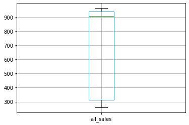

```python
top_5.boxplot();
```

#### Вывод

25% продаж по TOP-5 платформам составили менее 300 миллионов копий. Медиана близка к верхнему квартилю. Это означает, что 50% платформ продали около 900 миллионов копий. А еще 25% продали еще на 50 миллионов копий больше.  
Аномальных значений на диаграмме нет, ни одна платформа не продавала каое-то рекордное количество копий своих игр.

```python
top_5 = top_5.reset_index()
top_5_list = list(top_5['platform']) # создаю список платформ для фильтрации датафрейма
```

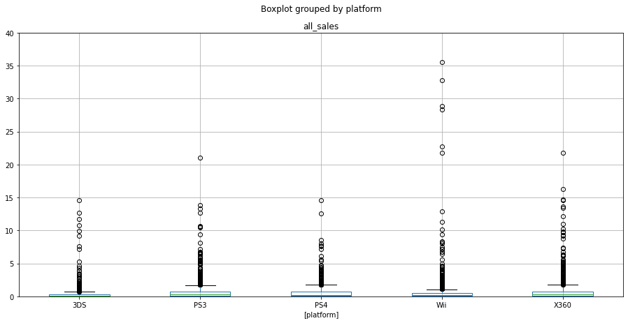

```python
forbp = df_actual.query('platform in @top_5_list')

boxplot = forbp.boxplot(column =['all_sales'], by = ['platform'], figsize = (15,7))
plt.ylim(0, 40);
```

```python
top_5_ab = top_5_ab.reset_index()
top_5_ab_list = list(top_5_ab['platform']) # создаю список платформ для фильтрации датафрейма
```

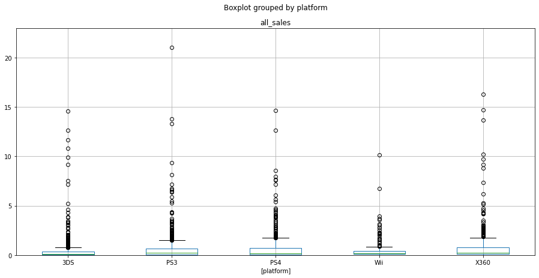

```python
forbp = df_alternative.query('platform in @top_5_list')

boxplot = forbp.boxplot(column =['all_sales'], by = ['platform'], figsize = (15,7))
plt.ylim(0, 23);
```

### Вывод

Для всех топ-5 платформ характерны большие выбросы и очень маленький "ящик". Это значит, что какие-то игры пользовались "бешенной" популярностью по сравнению с основной массой игр и их продажи зашкаливали. Самые далекие всплески "бешенной" популярность была на Wii.

🎈 В альтернативной выборке так же большие выбросы при маленьком "ящике". Самая популярная игра на PS3 далеко оторвалась ото всех.

Ниже посмотрю, что же это за игры такие.

```python
df_actual.query('platform == "Wii"').sort_values(by='all_sales', ascending=False).head(5)
```

|  | name | platform | year_of_release | genre | na_sales | eu_sales | jp_sales | other_sales | critic_score | user_score | rating | all_sales |
| --- | --- | --- | --- | --- | --- | --- | --- | --- | --- | --- | --- | --- |
| 0 | Wii Sports | Wii | 2006 | Sports | 41.36 | 28.96 | 3.77 | 8.45 | 76.0 | 8.0 | E | 82.54 |
| 1 | Mario Kart Wii | Wii | 2008 | Racing | 15.68 | 12.76 | 3.79 | 3.29 | 82.0 | 8.3 | E | 35.52 |
| 2 | Wii Sports Resort | Wii | 2009 | Sports | 15.61 | 10.93 | 3.28 | 2.95 | 80.0 | 8.0 | E | 32.77 |
| 3 | Wii Play | Wii | 2006 | Misc | 13.96 | 9.18 | 2.93 | 2.84 | 58.0 | 6.6 | E | 28.91 |
| 4 | New Super Mario Bros. Wii | Wii | 2009 | Platform | 14.44 | 6.94 | 4.70 | 2.24 | 87.0 | 8.4 | E | 28.32 |

```python
df_alternative.query('platform == "PS3"').sort_values(by='all_sales', ascending=False).head(5)
```

|  | name | platform | year_of_release | genre | na_sales | eu_sales | jp_sales | other_sales | critic_score | user_score | rating | all_sales |
| --- | --- | --- | --- | --- | --- | --- | --- | --- | --- | --- | --- | --- |
| 0 | Grand Theft Auto V | PS3 | 2013 | Action | 7.02 | 9.09 | 0.98 | 3.96 | 97.0 | 8.2 | M | 21.05 |
| 5 | Call of Duty: Black Ops II | PS3 | 2012 | Shooter | 4.99 | 5.73 | 0.65 | 2.42 | 83.0 | 5.3 | M | 13.79 |
| 7 | Call of Duty: Modern Warfare 3 | PS3 | 2011 | Shooter | 5.54 | 5.73 | 0.49 | 1.57 | 88.0 | 3.2 | M | 13.33 |
| 16 | Call of Duty: Ghosts | PS3 | 2013 | Shooter | 4.10 | 3.63 | 0.38 | 1.25 | 71.0 | 2.6 | M | 9.36 |
| 21 | FIFA Soccer 13 | PS3 | 2012 | Action | 1.06 | 5.01 | 0.13 | 1.97 | 88.0 | 6.6 | E | 8.17 |

### Исследование популярной платформы

Посмотрите, как влияют на продажи внутри одной популярной платформы отзывы пользователей и критиков. Постройте диаграмму рассеяния и посчитайте корреляцию между отзывами и продажами. Сформулируйте выводы.

#### Исследую продажи и влияние факторов на них на примере платформы X360

```python
x360 = df_actual.query('platform =="X360"')
x360.head()
```

|  | name | platform | year_of_release | genre | na_sales | eu_sales | jp_sales | other_sales | critic_score | user_score | rating | all_sales |
| --- | --- | --- | --- | --- | --- | --- | --- | --- | --- | --- | --- | --- |
| 6 | Kinect Adventures! | X360 | 2010 | Misc | 15.00 | 4.89 | 0.24 | 1.69 | 61.0 | 6.3 | E | 21.82 |
| 9 | Grand Theft Auto V | X360 | 2013 | Action | 9.66 | 5.14 | 0.06 | 1.41 | 97.0 | 8.1 | M | 16.27 |
| 10 | Call of Duty: Modern Warfare 3 | X360 | 2011 | Shooter | 9.04 | 4.24 | 0.13 | 1.32 | 88.0 | 3.4 | M | 14.73 |
| 12 | Call of Duty: Black Ops | X360 | 2010 | Shooter | 9.70 | 3.68 | 0.11 | 1.13 | 87.0 | 6.3 | M | 14.62 |
| 15 | Call of Duty: Black Ops II | X360 | 2012 | Shooter | 8.25 | 4.24 | 0.07 | 1.12 | 83.0 | 4.8 | M | 13.68 |

##### Влияние отзывов критиков на продажи

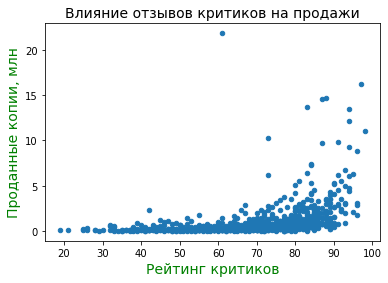

```python
x360.plot(x='critic_score', y='all_sales', kind='scatter')
plt.title('Влияние отзывов критиков на продажи', fontsize = 14)
plt.xlabel('Рейтинг критиков', color = 'green', fontsize = 14)
plt.ylabel('Проданные копии, млн', color = 'green', fontsize = 14);
```

```python
x360['critic_score'].corr(x360['all_sales'])
```

```
0.3971031004016887
```

##### АВ

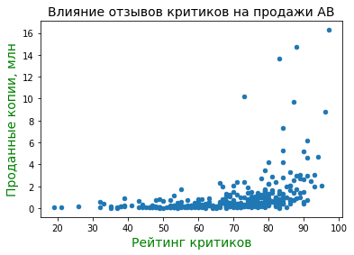

```python
x360_ab = df_alternative.query('platform =="X360"')
x360_ab.plot(x='critic_score', y='all_sales', kind='scatter')
plt.title('Влияние отзывов критиков на продажи АВ', fontsize = 14)
plt.xlabel('Рейтинг критиков', color = 'green', fontsize = 14)
plt.ylabel('Проданные копии, млн', color = 'green', fontsize = 14);
```

```python
x360_ab['critic_score'].corr(x360_ab['all_sales'])
```

```
0.39460224847059305
```

##### Вывод

Влияние отзывов критиков на продажи начинается после 70 баллов из 100. Все игры, рейтинг которых меньше 70 продаются примерно одинаково. Игры с рейтингом меньше 30 продаются очень мало. Возможно, потому что рейтинг начинает давать эффект только при высоких оценках, прямая зависимость между отзывами критиков и продажами всего 0.39.

🎈 Вывод не изменился. Дополнительные исследования подтвердили предыдущий вывод.

##### Влияние отзывов пользователей на продажи

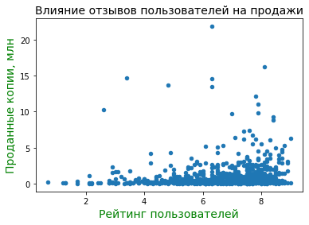

```python
x360.plot(x='user_score', y='all_sales', kind='scatter')
plt.title('Влияние отзывов пользователей на продажи', fontsize = 14)
plt.xlabel('Рейтинг пользователей', color = 'green', fontsize = 14)
plt.ylabel('Проданные копии, млн', color = 'green', fontsize = 14);
```

```python
x360['user_score'].corr(x360['all_sales'])
```

```
0.11595530948624756
```

##### АВ

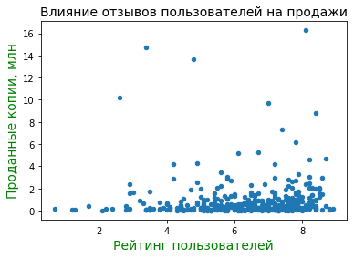

```python
x360_ab.plot(x='user_score', y='all_sales', kind='scatter')
plt.title('Влияние отзывов пользователей на продажи', fontsize = 14)
plt.xlabel('Рейтинг пользователей', color = 'green', fontsize = 14)
plt.ylabel('Проданные копии, млн', color = 'green', fontsize = 14);
```

```python
x360_ab['user_score'].corr(x360_ab['all_sales'])
```

```
0.03832736142896921
```

##### Вывод

🎈 В целом вывод не изменился, прямая зависимость продаж от рейтинга пользователей в последние пять лет стала еще меньше.